# NYC Ferry Stops EDA – Data Preparation + EDA

Simon

2026-03-01

```r
knitr::opts_chunk$set(
  echo = TRUE,
  message = FALSE,
  warning = FALSE,
  cache = TRUE
)
options(scipen = 999)

library(tidyverse)
library(lubridate)
library(stringr)
library(tibble)
library(scales)

base_dir <- "C:/Users/sungz/Box/NYC_Ferry/data/NYCF_data_compiled"
Sys.setlocale("LC_TIME", "English")
```

```
## [1] "English_United States.1252"
```

```r
tz_local <- "America/New_York"
```

## Overview

### Scope & sample definition

This notebook performs exploratory data analysis (EDA) on compiled NYC Ferry stop-level operations data.

All downstream analysis uses records from 2024-01-01 to 2025-06-30 (inclusive), and excludes 2024-04-25 for route `SB` due to a known schedule mismatch issue. Passenger activity is measured using `boarding_wake` and `alightings_wake` throughout.

### What this notebook produces

The notebook constructs a cleaned stop-level table, derives operational and reliability metrics (dwell, segment “water time,” delay, and late/early flags), and generates summary tables and plots across routes, months, and hours.

The final analysis sample is stored as `dat` (stop-level), which is also the only dataset exported at the end for downstream modeling and reporting.

## Data Preparation

### Import Data

The following code loads the compiled stop-level dataset and the ridership details dataset. Ridership details are used only to obtain vessel capacity for computing load factor.

```r
ridership_files <- c(
  file.path(base_dir, "ridership_details", "NYCF_ridership_details_2024.01_06.csv"),
  file.path(base_dir, "ridership_details", "NYCF_ridership_details_2024.07_12.csv"),
  file.path(base_dir, "ridership_details", "NYCF_ridership_details_2025.01_06.csv")
)

stop_files <- c(
  file.path(base_dir, "stop_data", "NYCF_stop_data_2024.csv"),
  file.path(base_dir, "stop_data", "NYCF_stop_data_2025.01_06.csv")
)

standardize_cols_ridership <- function(df) {
  nm <- names(df)
  nm <- ifelse(nm == "Original_On",  "Original_ON",  nm)
  nm <- ifelse(nm == "Original_Off", "Original_OFF", nm)
  nm <- ifelse(nm == "WheelChair_On",  "WheelChair_ON",  nm)
  nm <- ifelse(nm == "WheelChair_Off", "WheelChair_OFF", nm)
  names(df) <- nm
  df
}

ridership <- purrr::map_dfr(
  ridership_files,
  ~ readr::read_csv(.x, show_col_types = FALSE) %>%
    standardize_cols_ridership()
)

stops <- purrr::map_dfr(
  stop_files,
  ~ readr::read_csv(.x, show_col_types = FALSE)
)

glimpse(ridership)
```

```
## Rows: 961,890
## Columns: 15
## $ Date1           <chr> "1/1/2024", "1/1/2024", "1/1/2024", "1/1/2024", "1/1/2…
## $ Route           <chr> "ER", "ER", "ER", "ER", "ER", "ER", "ER", "ER", "ER", …
## $ Direction       <chr> "NB", "NB", "NB", "NB", "NB", "NB", "NB", "SB", "SB", …
## $ Trip_Pattern    <chr> "er_p11_gp_hps", "er_p11_gp_hps", "er_p11_gp_hps", "er…
## $ Trip_ID         <dbl> 1101, 1101, 1101, 1101, 1101, 1101, 1101, 1102, 1102, …
## $ Vessel_Id       <chr> "H201", "H201", "H201", "H201", "H201", "H201", "H201"…
## $ Vessel_Capacity <dbl> 150, 150, 150, 150, 150, 150, 150, 150, 150, 150, 150,…
## $ Stop            <chr> "Hunters Point South", "Wall St/Pier 11", "Dumbo/Fulto…
## $ Stop_Sequence   <dbl> NA, 1, 2, 3, 4, 5, 6, NA, 1, 2, 3, 4, 5, 6, NA, 1, 2, …
## $ Departure_Time  <time> 10:53:00, 10:05:00, 10:13:00, 10:25:00, 10:33:00, 10:…
## $ Original_ON     <dbl> 0, 8, 3, 1, 10, 16, 0, 0, 25, 37, 14, 13, 14, 12, 0, 2…
## $ Original_OFF    <dbl> 0, 0, 3, 2, 2, 4, 27, 35, 0, 13, 2, 15, 6, 44, 15, 0, …
## $ Left_Behind     <dbl> NA, NA, NA, NA, NA, NA, NA, NA, NA, NA, NA, NA, NA, NA…
## $ WheelChair_ON   <dbl> 0, 0, 0, 0, 0, 0, 0, 0, 0, 0, 0, 0, 0, 0, 0, 0, 0, 0, …
## $ WheelChair_OFF  <dbl> 0, 0, 0, 0, 0, 0, 0, 0, 0, 0, 0, 0, 0, 0, 0, 0, 0, 0, …
```

```r
glimpse(stops)
```

```
## Rows: 753,951
## Columns: 27
## $ Row_Number             <dbl> 1, 2, 3, 4, 5, 6, 7, 8, 9, 10, 11, 12, 13, 14, …
## $ `Sort Key`             <chr> "2024-01-011101ER  1", "2024-01-011101ER2", "20…
## $ vehicle_id             <chr> "H201", "H201", "H201", "H201", "H201", "H201",…
## $ trip_date              <chr> "1/1/2024", "1/1/2024", "1/1/2024", "1/1/2024",…
## $ trip_no                <dbl> 1101, 1101, 1101, 1101, 1101, 1101, 1101, 1102,…
## $ `Block Id`             <dbl> 11, 11, 11, 11, 11, 11, 11, 11, 11, 11, 11, 11,…
## $ route_no               <chr> "ER", "ER", "ER", "ER", "ER", "ER", "ER", "ER",…
## $ route_direction        <chr> "NB", "NB", "NB", "NB", "NB", "NB", "NB", "SB",…
## $ route_pattern          <chr> "er_p11_gp_hps", "er_p11_gp_hps", "er_p11_gp_hp…
## $ route_name             <chr> "East River", "East River", "East River", "East…
## $ stop_name              <chr> "Wall St/Pier 11", "Dumbo/Fulton Ferry", "South…
## $ scheduled_departure_dt <chr> "1/1/2024 10:05", "1/1/2024 10:13", "1/1/2024 1…
## $ scheduled_arrival_dt   <chr> NA, "1/1/2024 10:13", "1/1/2024 10:25", "1/1/20…
## $ actual_arrival_dt      <chr> NA, "1/1/2024 10:10", "1/1/2024 10:24", "1/1/20…
## $ actual_departure_dt    <chr> "1/1/2024 10:06", "1/1/2024 10:15", "1/1/2024 1…
## $ `Stop Sequence`        <dbl> 0, 1, 2, 3, 4, 5, 6, 2, 4, 5, 0, 1, 3, 6, 0, 5,…
## $ boarding_wake          <dbl> 8, 3, 1, 10, 16, 0, 0, 14, 14, 12, 25, 37, 13, …
## $ alightings_wake        <dbl> 0, 3, 2, 2, 4, 27, 0, 2, 6, 44, 0, 13, 15, 35, …
## $ alightings             <dbl> NA, NA, NA, NA, NA, NA, NA, NA, NA, NA, NA, NA,…
## $ boardings              <dbl> NA, NA, NA, NA, NA, NA, NA, NA, NA, NA, NA, NA,…
## $ lbr                    <dbl> NA, NA, NA, NA, NA, NA, NA, NA, NA, NA, NA, NA,…
## $ `Dwell Time`           <time> 00:04:49, 00:02:35, 00:03:06, 00:03:25, 00:03:…
## $ dept_variance_flag     <chr> "On_Time", "On_Time", "On_Time", "On_Time", "On…
## $ DepartureTimeVariance  <time> 00:01:16, 00:02:10, 00:02:06, 00:03:26, 00:04:…
## $ ArrivalTimeVariance    <time>       NA, 00:02:39, 00:00:29, 00:00:20, 00:00:…
## $ stop_id                <dbl> 87, 20, 8, 19, 18, 17, 4, 18, 8, 20, 4, 17, 19,…
## $ ...27                  <lgl> NA, NA, NA, NA, NA, NA, NA, NA, NA, NA, NA, NA,…
```

### Clean stops & build basic features

This step standardizes key fields and column names, cleans `Sort Key`, derives weekday/weekend indicators, and computes an onboard count per stop using cumulative `boarding_wake` minus `alightings_wake` within each trip ordered by `Stop_Sequence`.

```r
stops <- stops %>%
  mutate(`Sort Key` = str_replace_all(`Sort Key`, "\\s+", "")) %>%
  rename_with(~ str_replace_all(.x, "\\s+", "_")) %>%
  mutate(
    trip_no = as.character(trip_no),
    route_no = as.character(route_no),
    route_direction = as.character(route_direction),
    route_pattern = as.character(route_pattern),
    stop_name = as.character(stop_name),

    Stop_Sequence = as.integer(Stop_Sequence),
    sort_key_adj = paste0(str_sub(Sort_Key, 1, -2), Stop_Sequence),

    trip_date = mdy(trip_date),
    weekday = wday(trip_date, label = TRUE, abbr = FALSE),
    is_weekday = !wday(trip_date) %in% c(1, 7),

    lbr = coalesce(lbr, 0)
  ) %>%
  group_by(trip_date, trip_no, route_no, route_direction) %>%
  arrange(Stop_Sequence, .by_group = TRUE) %>%
  mutate(
    onboard = cumsum(coalesce(boarding_wake, 0)) - cumsum(coalesce(alightings_wake, 0))
  ) %>%
  ungroup() %>%
  select(-any_of(c("Row_Number", "Sort_Key", "route_name", "...27")))
```

### Parse datetimes (NY local time)

Stop timestamps appear in different string formats across years. We parse both formats into POSIXct and keep them in America/New_York so that time-of-day patterns reflect local operations.

```r
parse_dt_nycf <- function(x, tz_local) {
  x_chr <- as.character(x)
  x_chr <- str_trim(na_if(x_chr, ""))

  has_ampm <- str_detect(x_chr, regex("\\b(am|pm)\\b", ignore_case = TRUE))
  has_ampm[is.na(has_ampm)] <- FALSE

  out <- as.POSIXct(rep(NA, length(x_chr)), tz = tz_local)

  idx_2024 <- !has_ampm & !is.na(x_chr)   # "m/d/YYYY H:M"
  idx_2025 <-  has_ampm & !is.na(x_chr)   # "m/d/YYYY H:M(:S) AM/PM"

  out[idx_2024] <- mdy_hm(x_chr[idx_2024], tz = tz_local, quiet = TRUE)
  out[idx_2025] <- parse_date_time(
    x_chr[idx_2025],
    orders = c("mdY IMSp", "mdY IMp"),
    tz = tz_local,
    quiet = TRUE
  )

  out
}

stops <- stops %>%
  mutate(
    scheduled_arrival_dt   = parse_dt_nycf(scheduled_arrival_dt, tz_local),
    actual_arrival_dt      = parse_dt_nycf(actual_arrival_dt, tz_local),
    scheduled_departure_dt = parse_dt_nycf(scheduled_departure_dt, tz_local),
    actual_departure_dt    = parse_dt_nycf(actual_departure_dt, tz_local)
  )
```

### Enforce last-stop departure as missing

For each trip, the final stop should not have a meaningful departure timestamp. We explicitly set `actual_departure_dt` to missing for last stops to avoid incorrect dwell and segment calculations.

```r
stops <- stops %>%
  arrange(trip_date, trip_no, route_no, route_direction, Stop_Sequence) %>%
  mutate(
    actual_departure_dt = if_else(
      row_number() == n(),
      as.POSIXct(NA, tz = tz_local),
      actual_departure_dt
    ),
    .by = c(trip_date, trip_no, route_no, route_direction)
  )
```

### Compute delay / segment / dwell metrics

We compute arrival/departure delay relative to schedule, “water travel” time between consecutive stops (previous departure to current arrival), and dwell time at stops (arrival to departure). These derived metrics support distribution checks and late-rate analysis.

```r
stops <- stops %>%
  select(-any_of("dept_variance_flag")) %>%
  mutate(
    arr_diff = as.numeric(difftime(actual_arrival_dt, scheduled_arrival_dt, units = "mins")),
    dep_diff = as.numeric(difftime(actual_departure_dt, scheduled_departure_dt, units = "mins"))
  ) %>%
  arrange(trip_date, trip_no, route_no, route_direction, Stop_Sequence) %>%
  mutate(
    sched_water_min = as.numeric(difftime(scheduled_arrival_dt, lag(scheduled_departure_dt), units = "mins")),
    act_water_min   = as.numeric(difftime(actual_arrival_dt,    lag(actual_departure_dt),    units = "mins")),
    water_diff      = act_water_min - sched_water_min,
    .by = c(trip_date, trip_no, route_no, route_direction)
  ) %>%
  mutate(
    act_dwell_min = as.numeric(difftime(actual_departure_dt, actual_arrival_dt, units = "mins"))
  )
```

### Define lateness / earliness flags

We define Late arrival as `arr_diff` > 5 minutes and Early departure as `dep_diff` < -1 minute. These thresholds are used consistently throughout the reliability summaries and plots.

```r
stops <- stops %>%
  mutate(
    arr_status = case_when(
      is.na(arr_diff) ~ NA_character_,
      arr_diff > 5    ~ "Late",
      TRUE            ~ "Not_Late"
    ),
    dep_status = case_when(
      is.na(dep_diff) ~ NA_character_,
      dep_diff < -1   ~ "Early",
      TRUE            ~ "Not_Early"
    )
  )
```

### Join vessel capacity and compute load factor

We join `Vessel_Capacity` using four keys (`trip_date`, `route_pattern`, `trip_no`, `stop_name`) and compute `load_factor = onboard / Vessel_Capacity`.

```r
ridership_capacity_lookup <- ridership %>%
  transmute(
    trip_date     = mdy(Date1),
    route_pattern = as.character(Trip_Pattern),
    trip_no       = as.character(Trip_ID),
    stop_name     = as.character(Stop),
    Vessel_Capacity
  ) %>%
  filter(!is.na(Vessel_Capacity)) %>%
  distinct(trip_date, route_pattern, trip_no, stop_name, Vessel_Capacity)

stops <- stops %>%
  left_join(
    ridership_capacity_lookup,
    by = c(
      "trip_date" = "trip_date",
      "route_pattern" = "route_pattern",
      "trip_no" = "trip_no",
      "stop_name" = "stop_name"
    )
  ) %>%
  mutate(load_factor = onboard / Vessel_Capacity)
```

### Define analysis sample

We construct the final analysis table `dat` by applying the study period filter and removing the known problematic day/route subset. All EDA that follows is based on `dat` unless explicitly noted.

```r
dat0 <- stops %>%
  filter(trip_date >= ymd("2024-01-01"),
         trip_date <= ymd("2025-06-30"))

removed_0425_sb <- dat0 %>%
  filter(trip_date == ymd("2024-04-25") & route_no == "SB")

dat <- dat0 %>%
  filter(!(trip_date == ymd("2024-04-25") & route_no == "SB"))

tibble(
  min_trip_date = min(dat$trip_date, na.rm = TRUE),
  max_trip_date = max(dat$trip_date, na.rm = TRUE),
  n_rows_in_range_before_drop = nrow(dat0),
  n_rows_removed_2024_04_25_SB = nrow(removed_0425_sb),
  n_rows_final = nrow(dat)
)
```

```
## # A tibble: 1 × 5
##   min_trip_date max_trip_date n_rows_in_range_before_drop n_rows_removed_2024_…¹
##   <date>        <date>                              <int>                  <int>
## 1 2024-01-01    2025-06-30                         753951                    366
## # ℹ abbreviated name: ¹n_rows_removed_2024_04_25_SB
## # ℹ 1 more variable: n_rows_final <int>
```

## EDA Tables

### Derived tables

We create two helper tables to support EDA at different aggregation levels:

- `trip_tbl` summarizes one row per trip (useful for route/month/trip-start timing summaries).
- `dist_dat` keeps stop-level records with convenience fields (e.g., stop_volume, nonnegative onboard/load factor) for distributions and late-rate calculations.

```r
trip_tbl <- dat %>%
  mutate(trip_key = paste(trip_date, route_no, route_direction, trip_no, sep = "|")) %>%
  group_by(trip_key, trip_date, route_no, route_direction) %>%
  arrange(Stop_Sequence, .by_group = TRUE) %>%
  summarise(
    n_stops = n_distinct(stop_id),
    trip_boardings  = sum(boarding_wake, na.rm = TRUE),
    trip_alightings = sum(alightings_wake, na.rm = TRUE),
    trip_total_events = sum(boarding_wake + alightings_wake, na.rm = TRUE),
    trip_start_departure = first(actual_departure_dt),
    is_weekday = first(is_weekday),
    month = floor_date(first(trip_date), "month"),
    .groups = "drop"
  ) %>%
  mutate(
    day_type = if_else(is_weekday, "Weekday", "Weekend"),
    dep_hour = hour(trip_start_departure)
  )

dist_dat <- dat %>%
  mutate(
    boarding_wake = coalesce(boarding_wake, 0),
    alightings_wake = coalesce(alightings_wake, 0),
    stop_volume = boarding_wake + alightings_wake,
    dwell_min = act_dwell_min,
    onboard_nonneg = pmax(onboard, 0),
    load_factor_nonneg = onboard_nonneg / Vessel_Capacity
  )
```

### Route overview (Weekday vs Weekend)

Route-level summaries compare weekday and weekend patterns to distinguish commute-driven demand from leisure and discretionary travel. We report total trips, total boardings, and average boardings per trip by route.

```r
route_weekpart <- trip_tbl %>%
  group_by(route_no, day_type) %>%
  summarise(
    total_trips = n(),
    total_boardings = sum(trip_boardings, na.rm = TRUE),
    .groups = "drop"
  )

route_avg_weekpart <- trip_tbl %>%
  group_by(route_no, day_type) %>%
  summarise(
    avg_boardings_per_trip = mean(trip_boardings, na.rm = TRUE),
    n_trips = n(),
    .groups = "drop"
  )

route_summary_by_stops <- trip_tbl %>%
  group_by(route_no, route_direction, n_stops) %>%
  summarise(
    n_trips = n(),
    total_boardings = sum(trip_boardings, na.rm = TRUE),
    avg_boardings_per_trip = total_boardings / n_trips,
    .groups = "drop"
  ) %>%
  arrange(route_no, route_direction, n_stops)

route_weekpart %>% arrange(desc(total_boardings))
```

```
## # A tibble: 16 × 4
##    route_no day_type total_trips total_boardings
##    <chr>    <chr>          <int>           <dbl>
##  1 ER       Weekday        24863         2730172
##  2 AS       Weekday        15047         1533359
##  3 ER       Weekend         7541         1302644
##  4 SV       Weekday        14933          919075
##  5 SB       Weekday        18874          709380
##  6 AS       Weekend         4732          692798
##  7 RW       Weekday        11950          655102
##  8 SG       Weekday        19744          653251
##  9 SB       Weekend         5189          482218
## 10 RW       Weekend         4582          334244
## 11 SV       Weekend         4617          326769
## 12 SG       Weekend         6534          253360
## 13 GI       Weekend         1292           49853
## 14 GI       Weekday          444           22963
## 15 RR       Weekend           84            8951
## 16 RR       Weekday            6             900
```

```r
route_summary_by_stops
```

```
## # A tibble: 28 × 6
##    route_no route_direction n_stops n_trips total_boardings
##    <chr>    <chr>             <int>   <int>           <dbl>
##  1 AS       NB                    7    9705         1014103
##  2 AS       SB                    7   10074         1212054
##  3 ER       NB                    7   16037         2012111
##  4 ER       SB                    7   16367         2020705
##  5 GI       NB                    2     897           30485
##  6 GI       SB                    2     839           42331
##  7 RR       NB                    3      45            4085
##  8 RR       SB                    3      45            5766
##  9 RW       NB                    3    8511          505836
## 10 RW       SB                    3    8021          483510
## # ℹ 18 more rows
## # ℹ 1 more variable: avg_boardings_per_trip <dbl>
```

### Stop totals

Stop totals aggregate boardings and alightings across the analysis period to identify the highest-activity stops. These rankings help interpret which terminals or transfer points dominate system usage.

```r
stop_totals <- dat %>%
  group_by(stop_id, stop_name) %>%
  summarise(
    total_boardings = sum(boarding_wake, na.rm = TRUE),
    total_alightings = sum(alightings_wake, na.rm = TRUE),
    .groups = "drop"
  ) %>%
  arrange(desc(total_boardings))

stop_totals
```

```
## # A tibble: 25 × 4
##    stop_id stop_name           total_boardings total_alightings
##      <dbl> <chr>                         <dbl>            <dbl>
##  1      87 Wall St/Pier 11             2163272          2562409
##  2      17 East 34th Street            1404634          1566502
##  3      20 Dumbo/Fulton Ferry           990583           884817
##  4      19 North Williamsburg           560850           520351
##  5     113 East 90th St                 533628           489918
##  6      88 Rockaway                     438062           435374
##  7      18 Greenpoint                   431993           388197
##  8       4 Hunters Point South          417259           397537
##  9      89 Astoria                      414117           342461
## 10     137 St. George                   387301           331679
## # ℹ 15 more rows
```

### Monthly patterns

Monthly summaries provide a simple view of seasonality and demand shifts over time. We summarize trips and ridership by month, split by weekday vs weekend, and also compute average boardings per trip.

```r
monthly_weekpart <- trip_tbl %>%
  filter(month >= ymd("2024-01-01"), month <= ymd("2025-06-01")) %>%
  group_by(month, day_type) %>%
  summarise(
    total_trips = n(),
    total_boardings = sum(trip_boardings, na.rm = TRUE),
    .groups = "drop"
  ) %>%
  arrange(month, day_type)

monthly_avg_weekpart <- trip_tbl %>%
  filter(month >= ymd("2024-01-01"), month <= ymd("2025-06-01")) %>%
  group_by(month, day_type) %>%
  summarise(
    avg_boardings_per_trip = mean(trip_boardings, na.rm = TRUE),
    n_trips = n(),
    .groups = "drop"
  ) %>%
  arrange(month, day_type)

monthly_weekpart
```

```
## # A tibble: 36 × 4
##    month      day_type total_trips total_boardings
##    <date>     <chr>          <int>           <dbl>
##  1 2024-01-01 Weekday         5912          254505
##  2 2024-01-01 Weekend         1176           49751
##  3 2024-02-01 Weekday         5547          250456
##  4 2024-02-01 Weekend         1176           76538
##  5 2024-03-01 Weekday         5671          307774
##  6 2024-03-01 Weekend         1610          142854
##  7 2024-04-01 Weekday         6015          392494
##  8 2024-04-01 Weekend         1799          179812
##  9 2024-05-01 Weekday         6290          485912
## 10 2024-05-01 Weekend         1982          233380
## # ℹ 26 more rows
```

```r
monthly_avg_weekpart
```

```
## # A tibble: 36 × 4
##    month      day_type avg_boardings_per_trip n_trips
##    <date>     <chr>                     <dbl>   <int>
##  1 2024-01-01 Weekday                    43.0    5912
##  2 2024-01-01 Weekend                    42.3    1176
##  3 2024-02-01 Weekday                    45.2    5547
##  4 2024-02-01 Weekend                    65.1    1176
##  5 2024-03-01 Weekday                    54.3    5671
##  6 2024-03-01 Weekend                    88.7    1610
##  7 2024-04-01 Weekday                    65.3    6015
##  8 2024-04-01 Weekend                   100.0    1799
##  9 2024-05-01 Weekday                    77.3    6290
## 10 2024-05-01 Weekend                   118.     1982
## # ℹ 26 more rows
```

### Time-of-day patterns

Hourly patterns are summarized in two ways: (1) trip-level departure hour (using each trip’s first observed departure time), and (2) stop-level departure hour (using each stop’s `actual_departure_dt`). This helps distinguish “when trips start” from “when stop activity occurs” across the day.

```r
hour_weekpart <- trip_tbl %>%
  filter(!is.na(dep_hour)) %>%
  mutate(dep_hour = as.integer(dep_hour)) %>%
  group_by(dep_hour, day_type) %>%
  summarise(
    total_boardings = sum(trip_boardings, na.rm = TRUE),
    .groups = "drop"
  ) %>%
  arrange(dep_hour, day_type)

hour_breaks <- sort(unique(hour_weekpart$dep_hour))
```

```r
stop_hour_weekpart <- dat %>%
  filter(!is.na(actual_departure_dt)) %>%
  mutate(
    dep_hour = hour(actual_departure_dt),
    day_type = if_else(is_weekday, "Weekday", "Weekend")
  ) %>%
  filter(!is.na(dep_hour)) %>%
  group_by(dep_hour, day_type) %>%
  summarise(
    n_stop_departures = n(),
    total_boardings = sum(boarding_wake, na.rm = TRUE),
    avg_boardings_per_stop = total_boardings / n_stop_departures,
    .groups = "drop"
  ) %>%
  arrange(dep_hour, day_type)

stop_hour_breaks <- sort(unique(stop_hour_weekpart$dep_hour))

stop_hour_weekpart
```

```
## # A tibble: 35 × 5
##    dep_hour day_type n_stop_departures total_boardings avg_boardings_per_stop
##       <int> <chr>                <int>           <dbl>                  <dbl>
##  1        5 Weekday               3952           36452                   9.22
##  2        6 Weekday              20969          150588                   7.18
##  3        7 Weekday              34867          481665                  13.8
##  4        7 Weekend                226            2073                   9.17
##  5        8 Weekday              35072          661987                  18.9
##  6        8 Weekend               2531           18147                   7.17
##  7        9 Weekday              36180          405600                  11.2
##  8        9 Weekend               8745          107551                  12.3
##  9       10 Weekday              29757          310091                  10.4
## 10       10 Weekend               9459          161616                  17.1
## # ℹ 25 more rows
```

### Late rate patterns

Late rate is the primary reliability outcome in this EDA. We first report overall shares of late arrivals and early departures, then summarize late rates by route, month, weekday vs weekend, and by departure hour.

```r
arr_status_tab <- dist_dat %>%
  filter(!is.na(arr_status)) %>%
  count(arr_status, name = "n") %>%
  mutate(pct = n / sum(n)) %>%
  arrange(desc(n))

dep_status_tab <- dist_dat %>%
  filter(!is.na(dep_status)) %>%
  count(dep_status, name = "n") %>%
  mutate(pct = n / sum(n)) %>%
  arrange(desc(n))

arr_status_tab
```

```
## # A tibble: 2 × 3
##   arr_status      n    pct
##   <chr>       <int>  <dbl>
## 1 Not_Late   558419 0.931
## 2 Late        41247 0.0688
```

```r
dep_status_tab
```

```
## # A tibble: 2 × 3
##   dep_status      n     pct
##   <chr>       <int>   <dbl>
## 1 Not_Early  599844 0.998
## 2 Early        1155 0.00192
```

```r
late_dat <- dist_dat %>%
  filter(!is.na(arr_status)) %>%
  mutate(
    is_late = arr_status == "Late",
    month = floor_date(trip_date, "month"),
    day_type = if_else(is_weekday, "Weekday", "Weekend"),
    dep_hour = hour(actual_departure_dt)
  )
```

```r
late_by_route <- late_dat %>%
  group_by(route_no) %>%
  summarise(
    n = n(),
    pct_late = mean(is_late),
    .groups = "drop"
  ) %>%
  arrange(desc(pct_late))

late_by_route %>% head(30)
```

```
## # A tibble: 8 × 3
##   route_no      n pct_late
##   <chr>     <int>    <dbl>
## 1 RW        31870   0.185
## 2 SV        95635   0.0900
## 3 RR          172   0.0872
## 4 GI         1622   0.0660
## 5 SB       111056   0.0648
## 6 ER       191089   0.0578
## 7 AS       116669   0.0526
## 8 SG        51553   0.0435
```

```r
late_by_month <- late_dat %>%
  group_by(month, day_type) %>%
  summarise(
    n = n(),
    pct_late = mean(is_late),
    .groups = "drop"
  ) %>%
  arrange(month, day_type)

late_by_month
```

```
## # A tibble: 36 × 4
##    month      day_type     n pct_late
##    <date>     <chr>    <int>    <dbl>
##  1 2024-01-01 Weekday  24647   0.0394
##  2 2024-01-01 Weekend   4960   0.0756
##  3 2024-02-01 Weekday  23016   0.0374
##  4 2024-02-01 Weekend   5052   0.0954
##  5 2024-03-01 Weekday  23804   0.0436
##  6 2024-03-01 Weekend   7033   0.152
##  7 2024-04-01 Weekday  25555   0.0492
##  8 2024-04-01 Weekend   8033   0.0919
##  9 2024-05-01 Weekday  25981   0.0609
## 10 2024-05-01 Weekend   8548   0.0930
## # ℹ 26 more rows
```

```r
late_by_daytype <- late_dat %>%
  group_by(day_type) %>%
  summarise(
    n = n(),
    pct_late = mean(is_late),
    .groups = "drop"
  )

late_by_daytype
```

```
## # A tibble: 2 × 3
##   day_type      n pct_late
##   <chr>     <int>    <dbl>
## 1 Weekday  451367   0.0607
## 2 Weekend  148299   0.0934
```

```r
late_by_hour <- late_dat %>%
  filter(!is.na(dep_hour)) %>%
  group_by(dep_hour, day_type) %>%
  summarise(
    n = n(),
    pct_late = mean(is_late),
    .groups = "drop"
  ) %>%
  arrange(dep_hour, day_type)

late_hour_breaks <- sort(unique(late_by_hour$dep_hour))

late_by_hour
```

```
## # A tibble: 34 × 4
##    dep_hour day_type     n pct_late
##       <int> <chr>    <int>    <dbl>
##  1        5 Weekday   2549   0.0118
##  2        6 Weekday  14253   0.0149
##  3        7 Weekday  25748   0.0116
##  4        8 Weekday  26783   0.0286
##  5        8 Weekend   1582   0.0107
##  6        9 Weekday  27496   0.0293
##  7        9 Weekend   6560   0.0194
##  8       10 Weekday  24007   0.0276
##  9       10 Weekend   6970   0.0191
## 10       11 Weekday  18792   0.0188
## # ℹ 24 more rows
```

## EDA Figures

### Route-level figures

These figures visualize route-level differences in service volume and demand. Weekday vs weekend splits highlight routes that are more commute-oriented versus leisure-oriented.

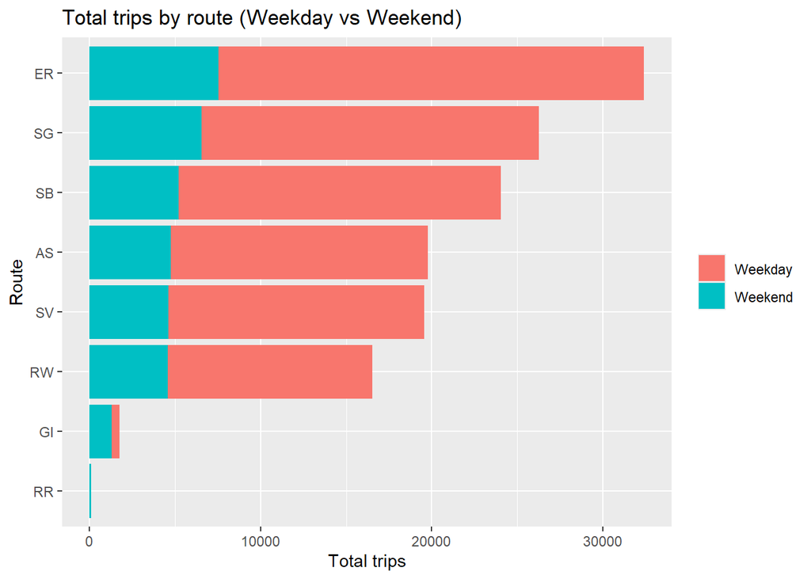

```r
ggplot(route_weekpart,
       aes(x = reorder(route_no, total_trips, FUN = sum),
           y = total_trips, fill = day_type)) +
  geom_col(position = "stack") +
  coord_flip() +
  labs(x = "Route", y = "Total trips", fill = NULL,
       title = "Total trips by route (Weekday vs Weekend)")
```

East River (ER) accounts for the largest share of trips in the system. Governors Island (GI) and Rockaway Rocket (RR) are seasonal services.

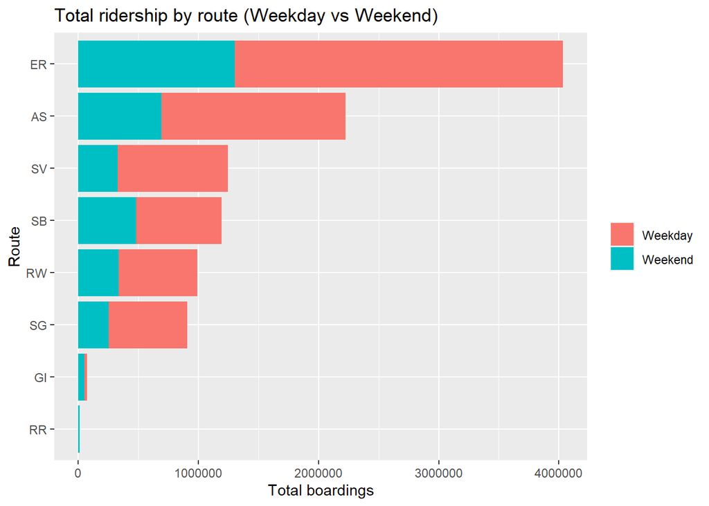

```r
ggplot(route_weekpart,
       aes(x = reorder(route_no, total_boardings, FUN = sum),
           y = total_boardings, fill = day_type)) +
  geom_col(position = "stack") +
  coord_flip() +
  labs(x = "Route", y = "Total boardings", fill = NULL,
       title = "Total ridership by route (Weekday vs Weekend)")
```

Total boardings are highest on East River (ER) and Astoria (AS).

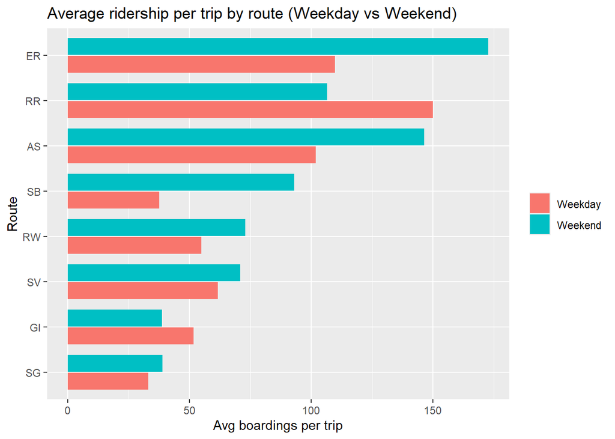

```r
ggplot(route_avg_weekpart,
       aes(x = reorder(route_no, avg_boardings_per_trip, FUN = max),
           y = avg_boardings_per_trip, fill = day_type)) +
  geom_col(position = position_dodge(width = 0.8), width = 0.75) +
  coord_flip() +
  labs(x = "Route", y = "Avg boardings per trip", fill = NULL,
       title = "Average ridership per trip by route (Weekday vs Weekend)")
```

Average boardings per trip tend to be higher on weekends than weekdays. For the seasonal routes, weekday averages can appear high because weekday service days are holiday/peak-operation days.

### Monthly figures

Monthly charts provide a high-level view of seasonality and temporal shifts in trips, total ridership, and average ridership per trip.

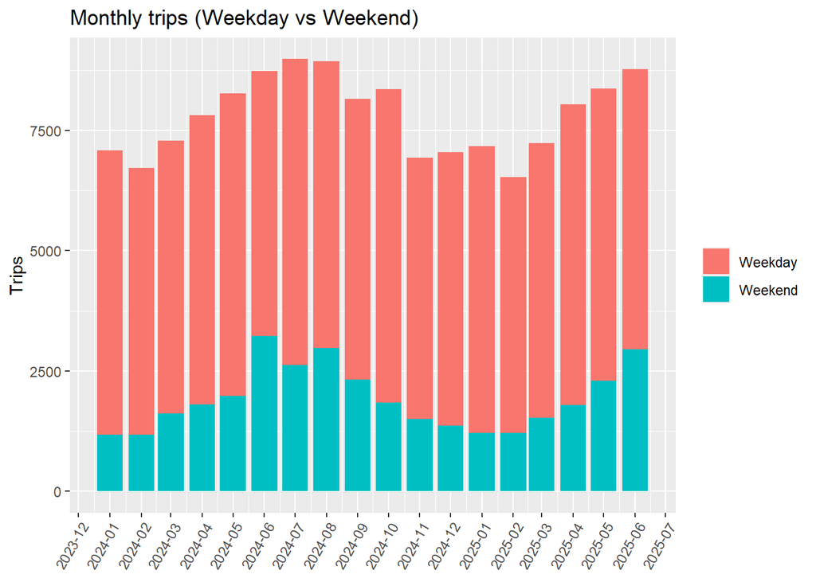

```r
ggplot(monthly_weekpart, aes(x = month, y = total_trips, fill = day_type)) +
  geom_col(position = "stack") +
  scale_x_date(date_breaks = "1 month", date_labels = "%Y-%m") +
  labs(x = NULL, y = "Trips", fill = NULL,
       title = "Monthly trips (Weekday vs Weekend)") +
  theme(axis.text.x = element_text(angle = 60, hjust = 1))
```

Weekday trip volumes are relatively stable month-to-month. Weekend trips show stronger seasonality, increasing in summer and decreasing in winter.

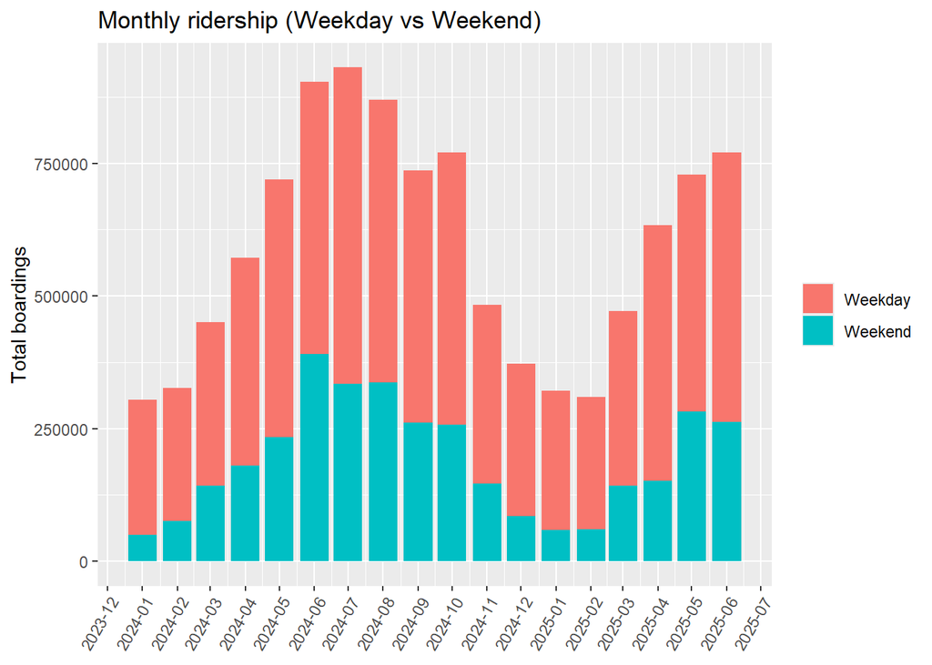

```r
ggplot(monthly_weekpart, aes(x = month, y = total_boardings, fill = day_type)) +
  geom_col(position = "stack") +
  scale_x_date(date_breaks = "1 month", date_labels = "%Y-%m") +
  labs(x = NULL, y = "Total boardings", fill = NULL,
       title = "Monthly ridership (Weekday vs Weekend)") +
  theme(axis.text.x = element_text(angle = 60, hjust = 1))
```

Ridership varies much more strongly by season than trips do, especially on weekends.

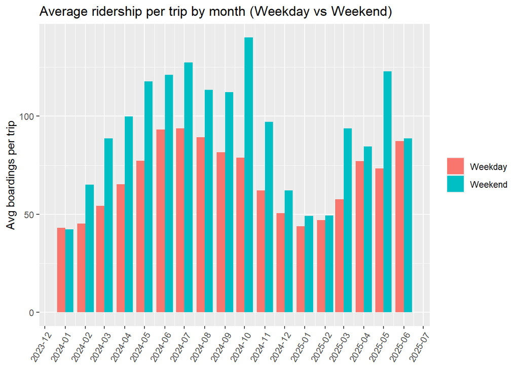

```r
ggplot(monthly_avg_weekpart, aes(x = month, y = avg_boardings_per_trip, fill = day_type)) +
  geom_col(position = position_dodge(width = 25), width = 25) +
  scale_x_date(date_breaks = "1 month", date_labels = "%Y-%m") +
  labs(x = NULL, y = "Avg boardings per trip", fill = NULL,
       title = "Average ridership per trip by month (Weekday vs Weekend)") +
  theme(axis.text.x = element_text(angle = 60, hjust = 1))
```

Weekday average boardings per trip change more smoothly over the year, while weekend values exhibit sharper peaks.

### Time-of-day figures

Time-of-day plots show how ridership and activity vary across hours. Trip-level and stop-level views are shown separately to capture differences between trip start times and stop departure activity.

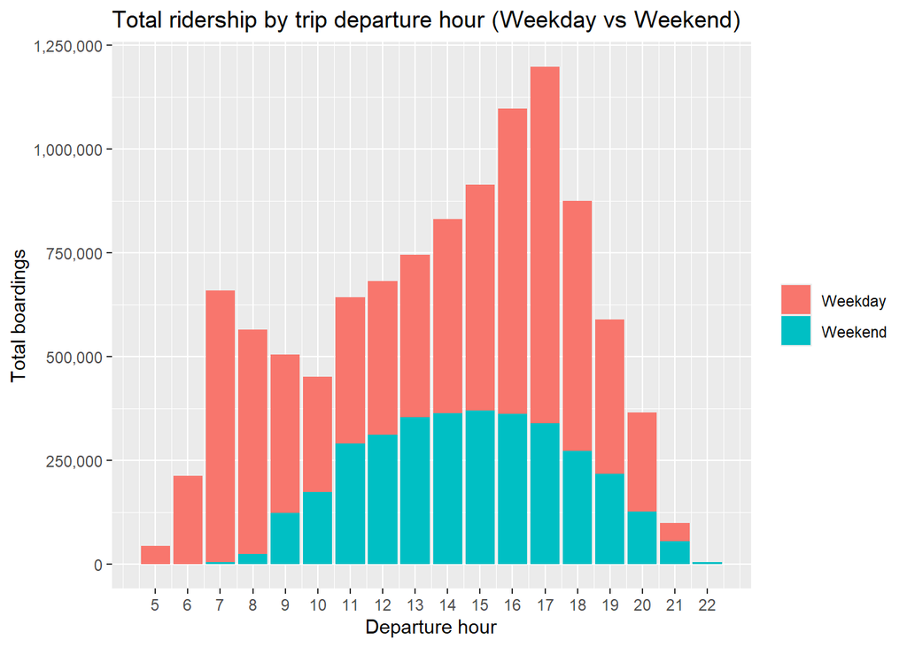

```r
ggplot(hour_weekpart, aes(x = dep_hour, y = total_boardings, fill = day_type)) +
  geom_col(position = "stack") +
  scale_x_continuous(breaks = hour_breaks) +
  scale_y_continuous(labels = scales::comma) +
  labs(title = "Total ridership by trip departure hour (Weekday vs Weekend)",
       x = "Departure hour", y = "Total boardings", fill = NULL)
```

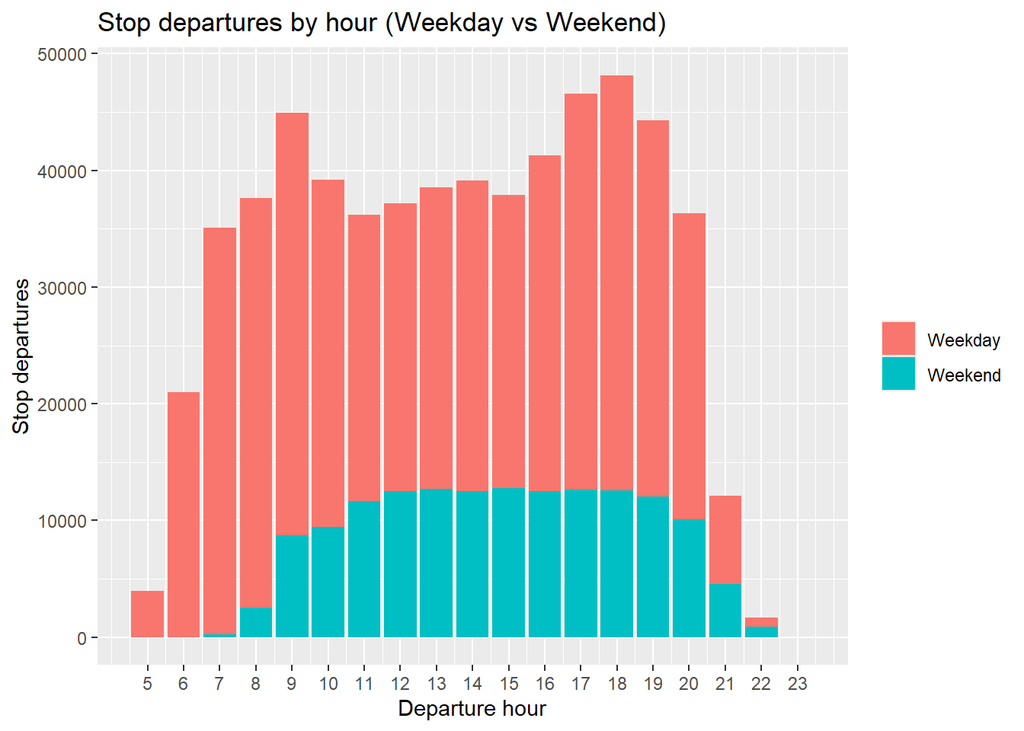

```r
ggplot(stop_hour_weekpart, aes(x = dep_hour, y = n_stop_departures, fill = day_type)) +
  geom_col(position = "stack") +
  scale_x_continuous(breaks = stop_hour_breaks) +
  labs(x = "Departure hour", y = "Stop departures", fill = NULL,
       title = "Stop departures by hour (Weekday vs Weekend)")
```

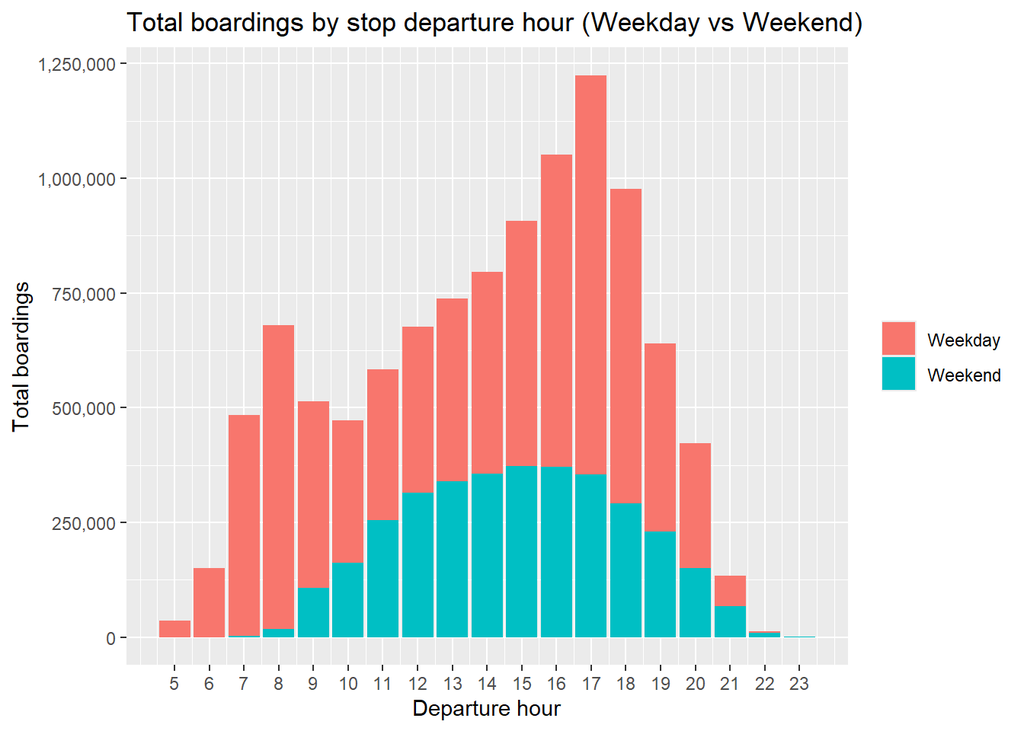

```r
ggplot(stop_hour_weekpart, aes(x = dep_hour, y = total_boardings, fill = day_type)) +
  geom_col(position = "stack") +
  scale_x_continuous(breaks = stop_hour_breaks) +
  scale_y_continuous(labels = scales::comma) +
  labs(x = "Departure hour", y = "Total boardings", fill = NULL,
       title = "Total boardings by stop departure hour (Weekday vs Weekend)")
```

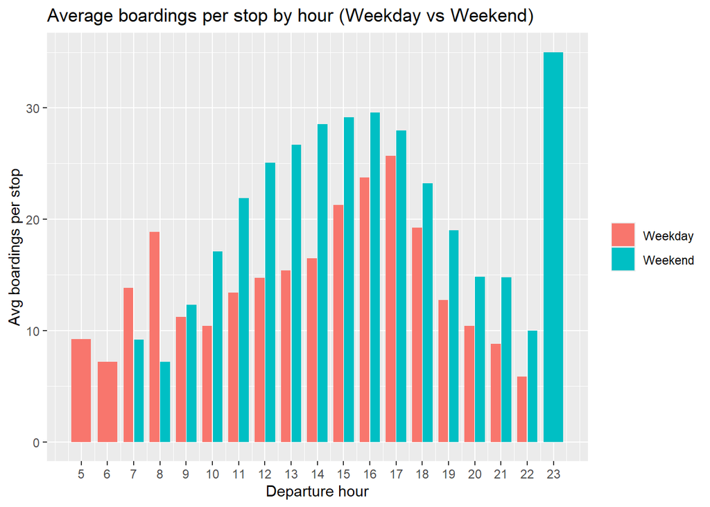

```r
ggplot(stop_hour_weekpart, aes(x = dep_hour, y = avg_boardings_per_stop, fill = day_type)) +
  geom_col(position = position_dodge(width = 0.8), width = 0.75) +
  scale_x_continuous(breaks = stop_hour_breaks) +
  labs(x = "Departure hour", y = "Avg boardings per stop", fill = NULL,
       title = "Average boardings per stop by hour (Weekday vs Weekend)")
```

On weekdays, stop activity shows morning and evening peaks consistent with commuting patterns. On weekends, higher activity is concentrated from midday through early evening.

### Distributions

Distribution plots are used as diagnostics to understand skew, outliers, and reasonable ranges for modeling (e.g., passenger counts, onboard/load factor, delay components, and dwell times). These figures are intended to guide feature engineering and robustness checks.

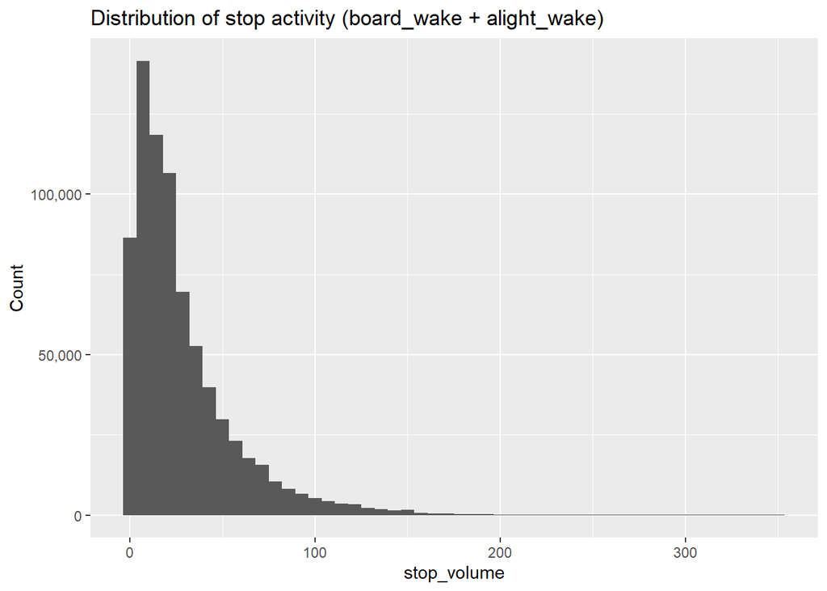

```r
ggplot(dist_dat %>% filter(!is.na(stop_volume), stop_volume >= 0, stop_volume <= 350),
       aes(x = stop_volume)) +
  geom_histogram(bins = 50) +
  scale_y_continuous(labels = scales::comma) +
  labs(title = "Distribution of stop activity (board_wake + alight_wake)",
       x = "stop_volume", y = "Count")
```

Stop activity is highly right-skewed with a long tail: most stops have relatively low combined boardings/alightings, while a small number of high-activity stops drive the upper tail. The majority of observations are below ~50 per stop.

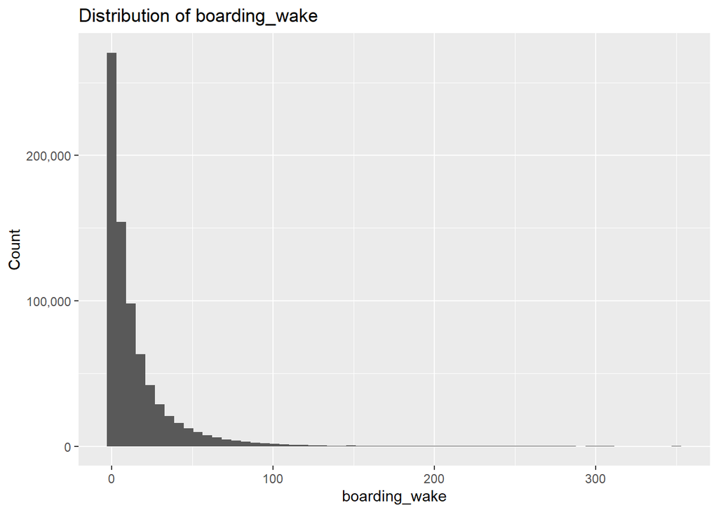

```r
ggplot(dist_dat %>% filter(boarding_wake >= 0, boarding_wake <= 350),
       aes(x = boarding_wake)) +
  geom_histogram(bins = 60) +
  scale_y_continuous(labels = scales::comma) +
  labs(title = "Distribution of boarding_wake",
       x = "boarding_wake", y = "Count")
```

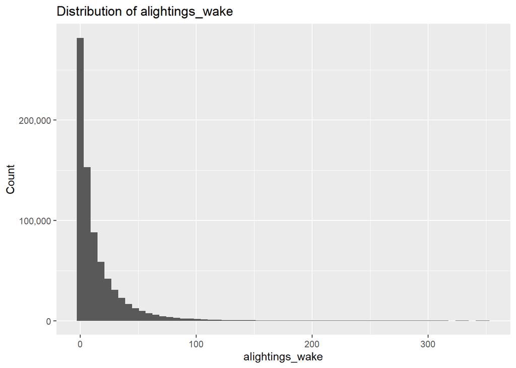

```r
ggplot(dist_dat %>% filter(alightings_wake >= 0, alightings_wake <= 350),
       aes(x = alightings_wake)) +
  geom_histogram(bins = 60) +
  scale_y_continuous(labels = scales::comma) +
  labs(title = "Distribution of alightings_wake",
       x = "alightings_wake", y = "Count")
```

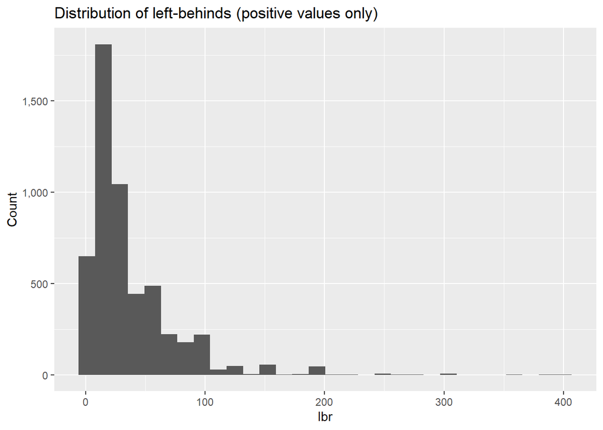

```r
ggplot(dist_dat %>% filter(!is.na(lbr) & lbr > 0),
       aes(x = lbr)) +
  geom_histogram(bins = 30) +
  scale_y_continuous(labels = scales::comma) +
  labs(title = "Distribution of left-behinds (positive values only)",
       x = "lbr", y = "Count")
```

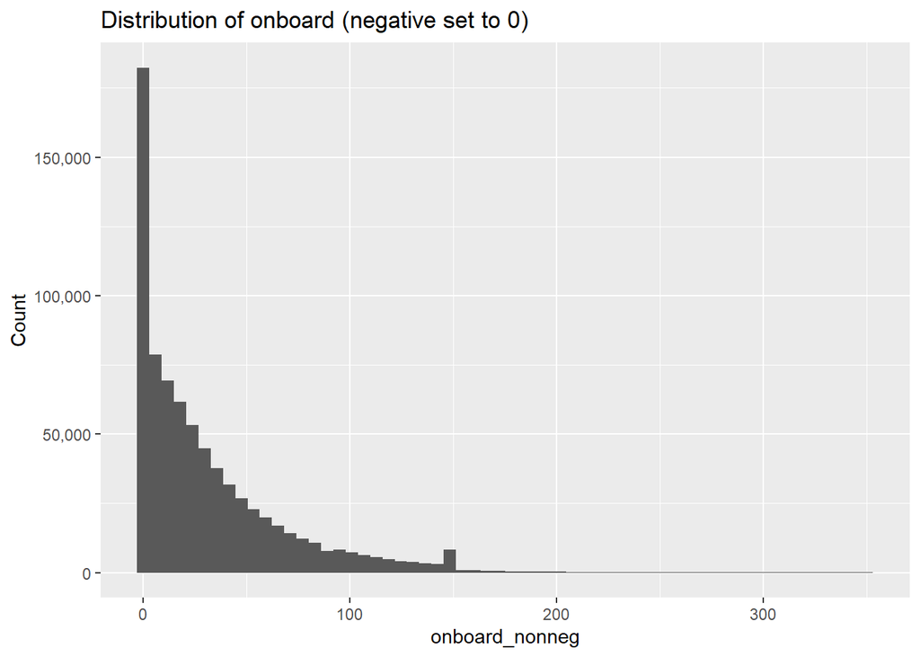

```r
ggplot(dist_dat %>% filter(!is.na(onboard_nonneg), onboard_nonneg <= 400),
       aes(x = onboard_nonneg)) +
  geom_histogram(bins = 60) +
  scale_y_continuous(labels = scales::comma) +
  labs(title = "Distribution of onboard (negative set to 0)",
       x = "onboard_nonneg", y = "Count")
```

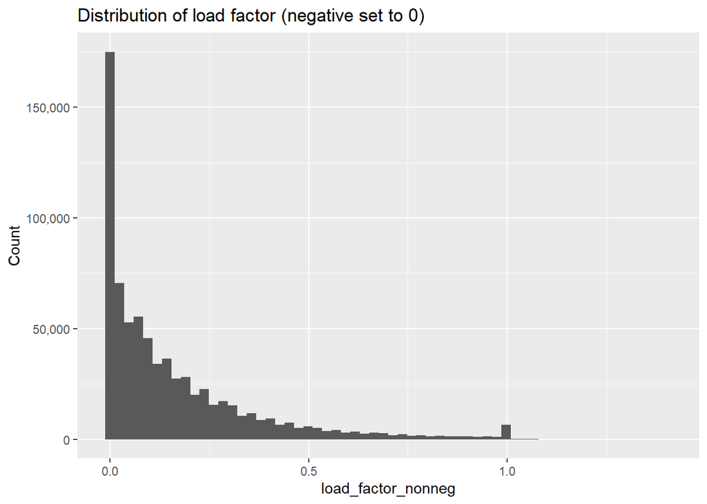

```r
ggplot(dist_dat %>% filter(!is.na(load_factor_nonneg), load_factor_nonneg <= 1.5),
       aes(x = load_factor_nonneg)) +
  geom_histogram(bins = 60) +
  scale_y_continuous(labels = scales::comma) +
  labs(title = "Distribution of load factor (negative set to 0)",
       x = "load_factor_nonneg", y = "Count")
```

Onboard and load factor are also long-tailed, with most observations at low occupancy (e.g., load factor < 0.25). A small secondary peak at full capacity indicates sold-out trips.

```r
arr_diff_bins <- dat %>%
  filter(!is.na(arr_diff), arr_diff >= -20, arr_diff <= 75) %>%
  mutate(bin_5min = floor(arr_diff / 5) * 5) %>%
  count(bin_5min, name = "n") %>%
  arrange(bin_5min) %>%
  mutate(
    pct = n / sum(n),
    cum_pct = cumsum(pct)
  )

arr_diff_bins
```

```
## # A tibble: 18 × 4
##    bin_5min      n        pct    cum_pct
##       <dbl>  <int>      <dbl>      <dbl>
##  1      -20      2 0.00000334 0.00000334
##  2      -15     23 0.0000384  0.0000417
##  3      -10   5509 0.00919    0.00923
##  4       -5 340210 0.567      0.577
##  5        0 203547 0.339      0.916
##  6        5  35231 0.0588     0.975
##  7       10   8676 0.0145     0.989
##  8       15   3315 0.00553    0.995
##  9       20   1515 0.00253    0.997
## 10       25    823 0.00137    0.999
## 11       30    398 0.000664   0.999
## 12       35    216 0.000360   1.000
## 13       40    138 0.000230   1.000
## 14       45     40 0.0000667  1.000
## 15       50     15 0.0000250  1.000
## 16       55      3 0.00000500 1.000
## 17       60      3 0.00000500 1.000
## 18       70      2 0.00000334 1
```

At the stop level, 8.4% of stops exceed the late threshold, and 2.5% are excessively late. Trip-level late rates will be higher if a trip is labeled late when any stop on that trip is late.

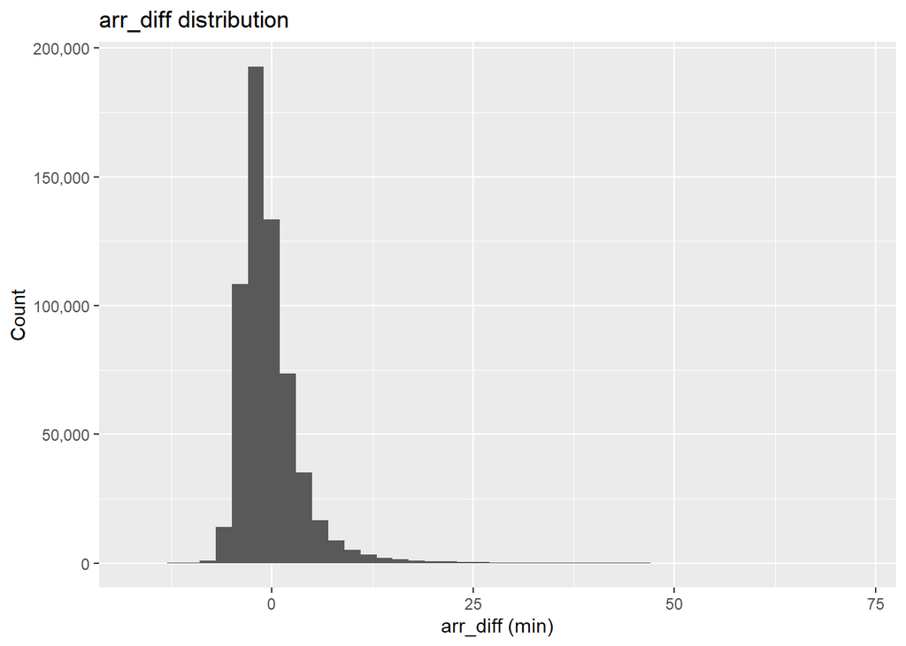

```r
ggplot(dist_dat %>% filter(!is.na(arr_diff)),
       aes(x = arr_diff)) +
  geom_histogram(binwidth = 2) +
  scale_y_continuous(labels = scales::comma) +
  labs(title = "arr_diff distribution",
       x = "arr_diff (min)", y = "Count")
```

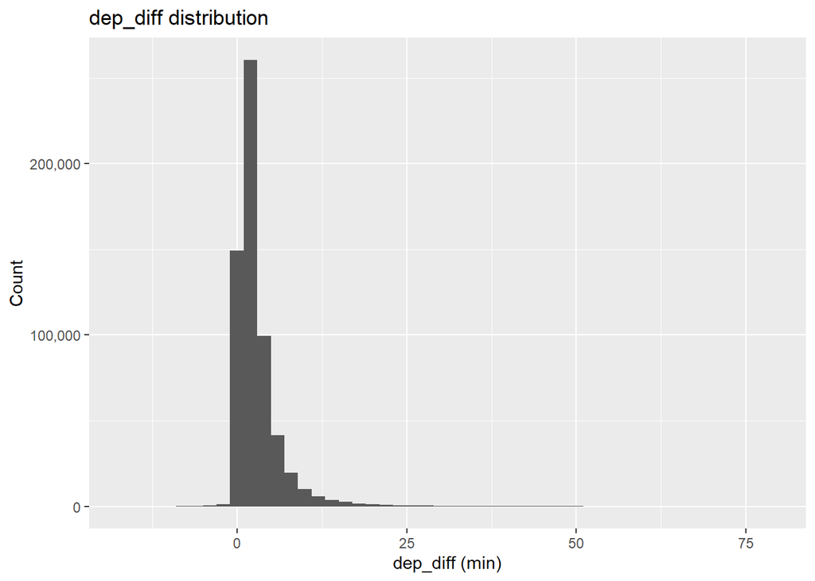

```r
ggplot(dist_dat %>% filter(!is.na(dep_diff)),
       aes(x = dep_diff)) +
  geom_histogram(binwidth = 2) +
  scale_y_continuous(labels = scales::comma) +
  labs(title = "dep_diff distribution",
       x = "dep_diff (min)", y = "Count")
```

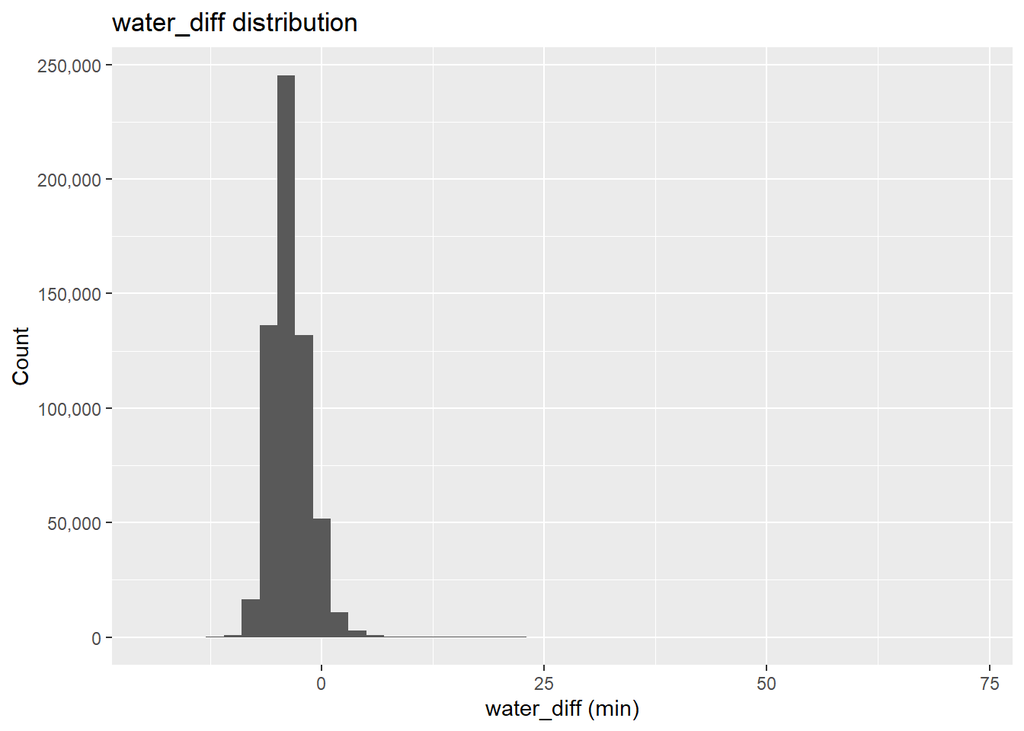

```r
ggplot(dist_dat %>% filter(!is.na(water_diff)),
       aes(x = water_diff)) +
  geom_histogram(binwidth = 2) +
  scale_y_continuous(labels = scales::comma) +
  labs(title = "water_diff distribution",
       x = "water_diff (min)", y = "Count")
```

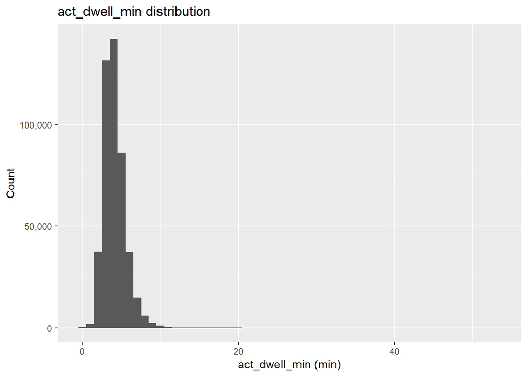

```r
ggplot(dist_dat %>% filter(!is.na(act_dwell_min), act_dwell_min >= 0, act_dwell_min <= 60),
       aes(x = act_dwell_min)) +
  geom_histogram(binwidth = 1) +
  scale_y_continuous(labels = scales::comma) +
  labs(title = "act_dwell_min distribution",
       x = "act_dwell_min (min)", y = "Count")
```

Because scheduled arrival and departure times are identical in the raw schedule data (i.e., no scheduled dwell), arrivals can appear slightly early while departures appear slightly late. In practice, realized dwell time helps reconcile these differences, and dwell times cluster in 3 to 5-minute range.

### Late-rate figures

These figures visualize how late rate varies across routes, months, and hours. The goal is to highlight patterns in reliability rather than interpret individual delay magnitudes.

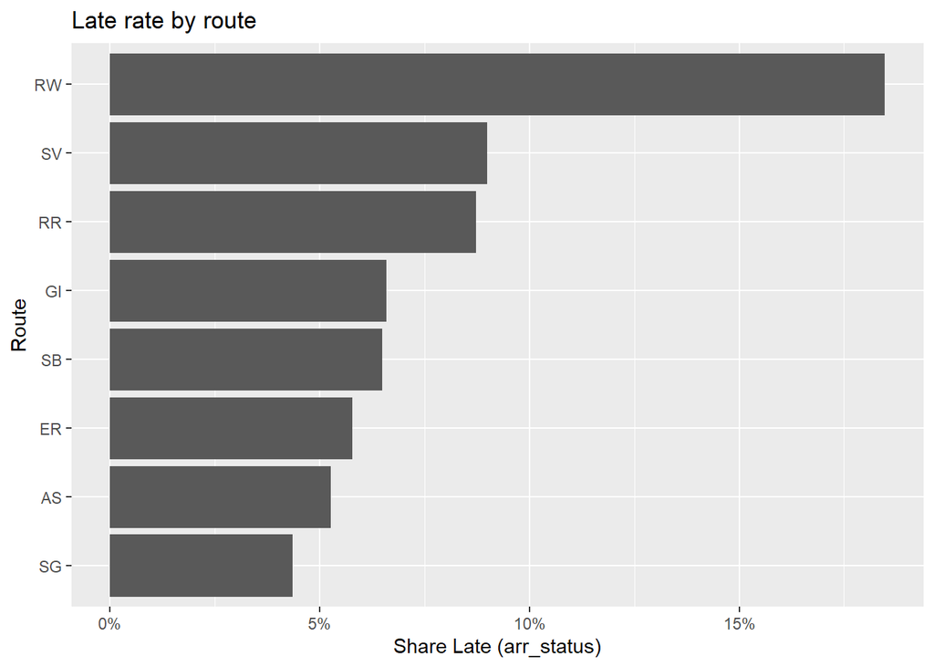

```r
ggplot(late_by_route, aes(x = reorder(route_no, pct_late), y = pct_late)) +
  geom_col() +
  coord_flip() +
  scale_y_continuous(labels = scales::percent_format()) +
  labs(title = "Late rate by route",
       x = "Route", y = "Share Late (arr_status)")
```

Rockaway (RW) has the highest late rate by a wide margin relative to other routes. It is the longest route and more exposed to high seasonal peaks and variable marine conditions.

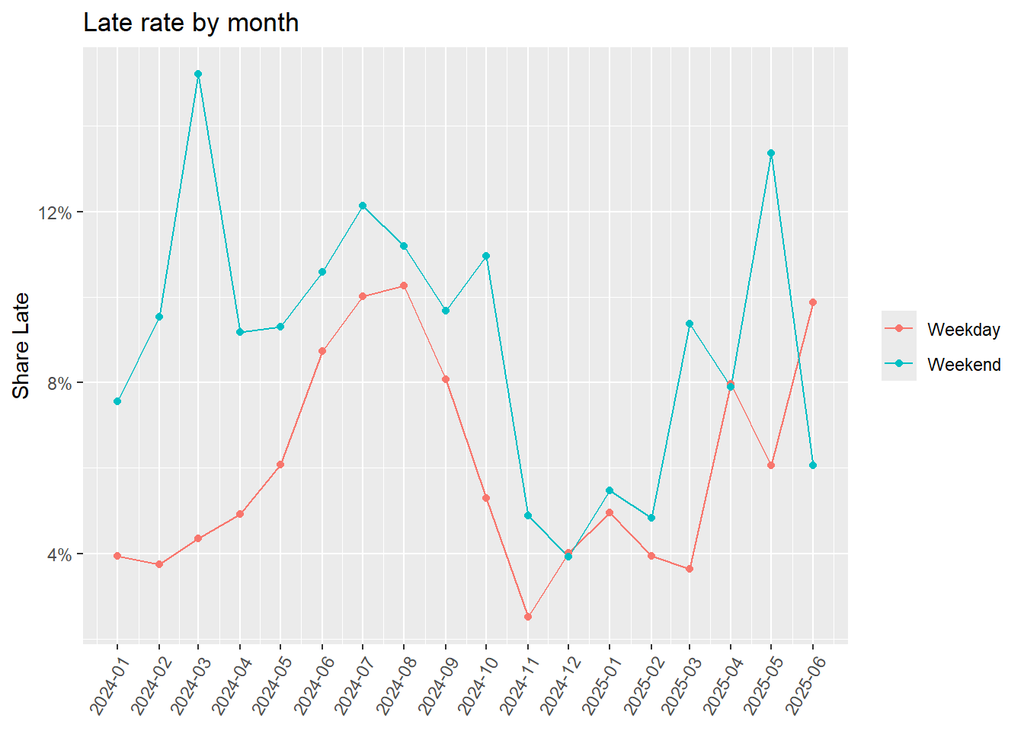

```r
ggplot(late_by_month, aes(x = month, y = pct_late, color = day_type)) +
  geom_line() +
  geom_point() +
  scale_x_date(date_breaks = "1 month", date_labels = "%Y-%m") +
  scale_y_continuous(labels = scales::percent_format()) +
  labs(title = "Late rate by month",
       x = NULL, y = "Share Late", color = NULL) +
  theme(axis.text.x = element_text(angle = 60, hjust = 1))
```

Late rates are generally higher in summer than winter, and higher on weekends than weekdays.

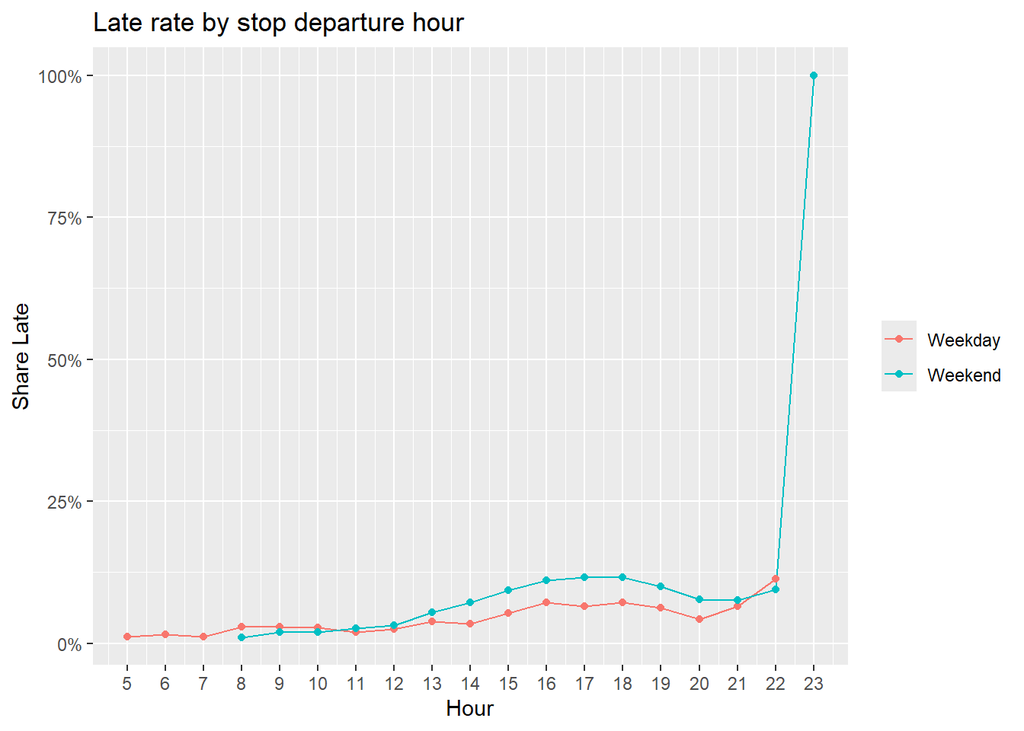

```r
ggplot(late_by_hour, aes(x = dep_hour, y = pct_late, color = day_type)) +
  geom_line() +
  geom_point() +
  scale_x_continuous(breaks = late_hour_breaks) +
  scale_y_continuous(labels = scales::percent_format()) +
  labs(title = "Late rate by stop departure hour",
       x = "Hour", y = "Share Late", color = NULL)
```

### Late propagation proxy figures

To proxy delay propagation along a trip, we relate a stop’s lateness to conditions at the previous stop. We show late rates binned by previous-stop dwell time and by previous-stop passenger activity (`boarding_wake + alightings_wake`).

```r
prev_dat <- dist_dat %>%
  arrange(trip_date, route_no, route_direction, trip_no, Stop_Sequence) %>%
  group_by(trip_date, route_no, route_direction, trip_no) %>%
  mutate(
    prev_dwell_min   = lag(dwell_min),
    prev_stop_volume = lag(stop_volume)
  ) %>%
  ungroup() %>%
  filter(!is.na(arr_status),
         !is.na(prev_dwell_min), prev_dwell_min >= 0, prev_dwell_min <= 60,
         !is.na(prev_stop_volume), prev_stop_volume >= 0)
```

```r
prev_dwell_late_tbl <- prev_dat %>%
  mutate(
    prev_dwell_bin = cut(prev_dwell_min,
                         breaks = c(0, 1, 2, 3, 5, 8, 12, 16, Inf),
                         include.lowest = TRUE)
  ) %>%
  group_by(prev_dwell_bin) %>%
  summarise(
    n = n(),
    pct_late = mean(arr_status == "Late", na.rm = TRUE),
    .groups = "drop"
  )

prev_dwell_late_tbl
```

```
## # A tibble: 8 × 3
##   prev_dwell_bin      n pct_late
##   <fct>           <int>    <dbl>
## 1 [0,1]            2041   0.111
## 2 (1,2]           26936   0.108
## 3 (2,3]          117033   0.0843
## 4 (3,5]          239932   0.0633
## 5 (5,8]           68604   0.0814
## 6 (8,12]           4537   0.232
## 7 (12,16]            98   0.612
## 8 (16,Inf]           46   0.978
```

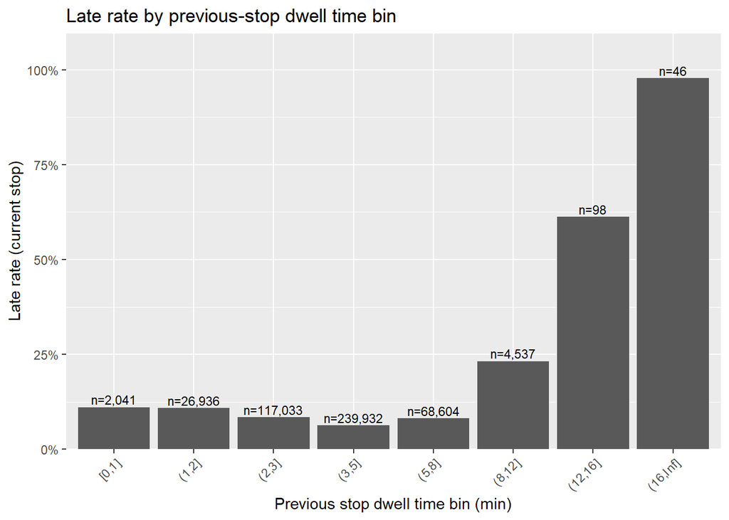

```r
ggplot(prev_dwell_late_tbl, aes(x = prev_dwell_bin, y = pct_late)) +
  geom_col() +
  geom_text(aes(label = paste0("n=", scales::comma(n))),
            vjust = -0.3, size = 3) +
  scale_y_continuous(labels = scales::percent_format(),
                     expand = expansion(mult = c(0, 0.12))) +
  labs(title = "Late rate by previous-stop dwell time bin",
       x = "Previous stop dwell time bin (min)", y = "Late rate (current stop)") +
  theme(axis.text.x = element_text(angle = 45, hjust = 1))
```

Within typical dwell time ranges, the relationship between previous-stop dwell and current-stop late rate is relatively weak. Once previous-stop dwell becomes unusually long (e.g., > ~8 minutes), late rates increase sharply.

```r
prev_vol_late_tbl <- prev_dat %>%
  mutate(
    prev_vol_bin = cut(prev_stop_volume,
                       breaks = c(0, 10, 20, 30, 50, 100, 150, 200, Inf),
                       include.lowest = TRUE)
  ) %>%
  group_by(prev_vol_bin) %>%
  summarise(
    n = n(),
    pct_late = mean(arr_status == "Late", na.rm = TRUE),
    .groups = "drop"
  )

prev_vol_late_tbl
```

```
## # A tibble: 8 × 3
##   prev_vol_bin      n pct_late
##   <fct>         <int>    <dbl>
## 1 [0,10]       134481   0.0540
## 2 (10,20]      105747   0.0544
## 3 (20,30]       71734   0.0677
## 4 (30,50]       78063   0.0873
## 5 (50,100]      56688   0.129
## 6 (100,150]     11025   0.220
## 7 (150,200]      1332   0.335
## 8 (200,Inf]       157   0.573
```

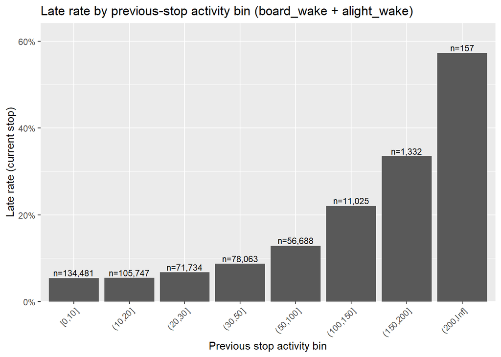

```r
ggplot(prev_vol_late_tbl, aes(x = prev_vol_bin, y = pct_late)) +
  geom_col() +
  geom_text(aes(label = paste0("n=", scales::comma(n))),
            vjust = -0.3, size = 3) +
  scale_y_continuous(labels = scales::percent_format(),
                     expand = expansion(mult = c(0, 0.12))) +
  labs(title = "Late rate by previous-stop activity bin (board_wake + alight_wake)",
       x = "Previous stop activity bin", y = "Late rate (current stop)") +
  theme(axis.text.x = element_text(angle = 45, hjust = 1))
```

When previous-stop activity is moderate, late rates change gradually; beyond higher activity levels (e.g., > ~50), late rates rise more noticeably.

### Direction comparison figures (NB vs SB)

Directional comparisons (`NB` vs `SB`) are computed at the trip level and summarized by departure hour. Faceted plots by route help identify persistent directional asymmetry in both demand and reliability, separately for weekdays and weekends.

```r
trip_dir_tbl <- dat %>%
  filter(route_direction %in% c("NB", "SB")) %>%
  arrange(trip_date, route_no, route_direction, trip_no, Stop_Sequence) %>%
  group_by(trip_date, route_no, route_direction, trip_no) %>%
  summarise(
    is_weekday = first(is_weekday),
    trip_boardings = sum(boarding_wake, na.rm = TRUE),
    trip_dep_dt = first(actual_departure_dt),
    trip_late_rate = mean(arr_status == "Late", na.rm = TRUE),
    .groups = "drop"
  ) %>%
  mutate(
    day_type = if_else(is_weekday, "Weekday", "Weekend"),
    dep_hour = hour(trip_dep_dt)
  ) %>%
  filter(!is.na(dep_hour))

dir_hour_summary <- trip_dir_tbl %>%
  group_by(route_no, route_direction, dep_hour, day_type) %>%
  summarise(
    n_trips = n(),
    avg_boardings_per_trip = mean(trip_boardings, na.rm = TRUE),
    avg_late_rate = mean(trip_late_rate, na.rm = TRUE),
    .groups = "drop"
  )

dir_hour_summary %>% head(30)
```

```
## # A tibble: 30 × 7
##    route_no route_direction dep_hour day_type n_trips avg_boardings_per_trip
##    <chr>    <chr>              <int> <chr>      <int>                  <dbl>
##  1 AS       NB                     6 Weekday      365                   54.6
##  2 AS       NB                     7 Weekday      731                   72.6
##  3 AS       NB                     8 Weekday      711                   61.9
##  4 AS       NB                     8 Weekend       83                   42.9
##  5 AS       NB                     9 Weekday      412                   47.9
##  6 AS       NB                     9 Weekend      170                   71.2
##  7 AS       NB                    10 Weekday      387                   55.3
##  8 AS       NB                    10 Weekend      190                   88.0
##  9 AS       NB                    11 Weekday      384                   61.8
## 10 AS       NB                    11 Weekend      205                  106.
## # ℹ 20 more rows
## # ℹ 1 more variable: avg_late_rate <dbl>
```

```r
dir_hour_breaks <- sort(unique(dir_hour_summary$dep_hour))
```

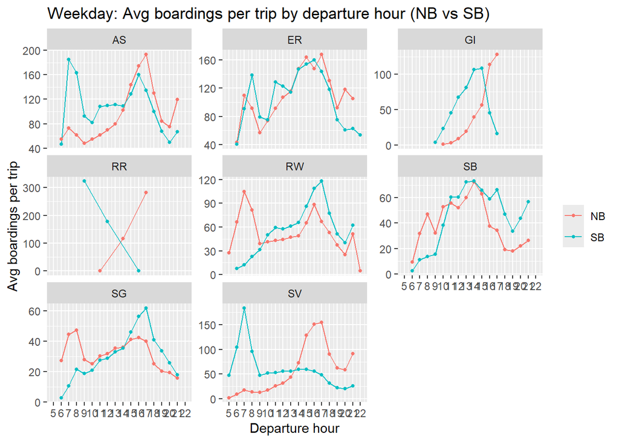

```r
ggplot(dir_hour_summary %>% filter(day_type == "Weekday"),
       aes(x = dep_hour, y = avg_boardings_per_trip, color = route_direction)) +
  geom_line() +
  geom_point(size = 1) +
  facet_wrap(~ route_no, scales = "free_y") +
  scale_x_continuous(breaks = dir_hour_breaks) +
  labs(title = "Weekday: Avg boardings per trip by departure hour (NB vs SB)",
       x = "Departure hour", y = "Avg boardings per trip", color = NULL)
```

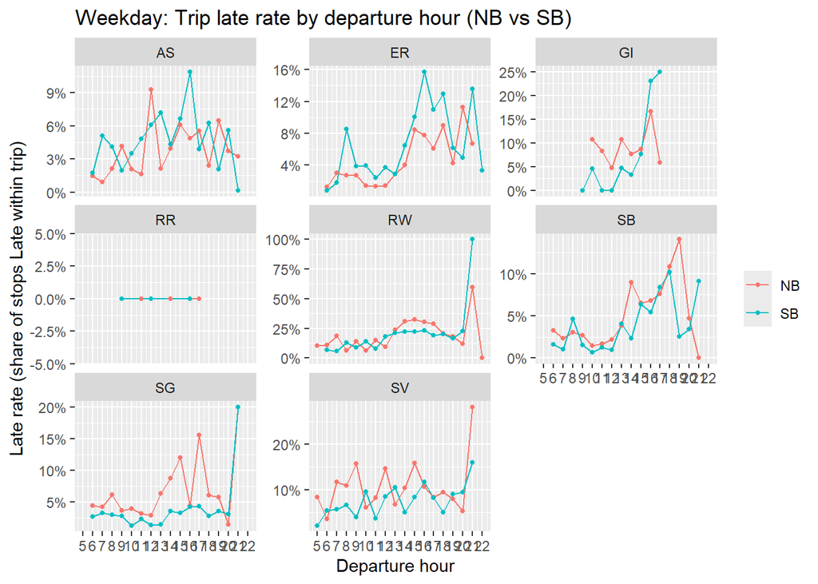

```r
ggplot(dir_hour_summary %>% filter(day_type == "Weekday"),
       aes(x = dep_hour, y = avg_late_rate, color = route_direction)) +
  geom_line() +
  geom_point(size = 1) +
  facet_wrap(~ route_no, scales = "free_y") +
  scale_x_continuous(breaks = dir_hour_breaks) +
  scale_y_continuous(labels = scales::percent_format()) +
  labs(title = "Weekday: Trip late rate by departure hour (NB vs SB)",
       x = "Departure hour", y = "Late rate (share of stops Late within trip)", color = NULL)
```

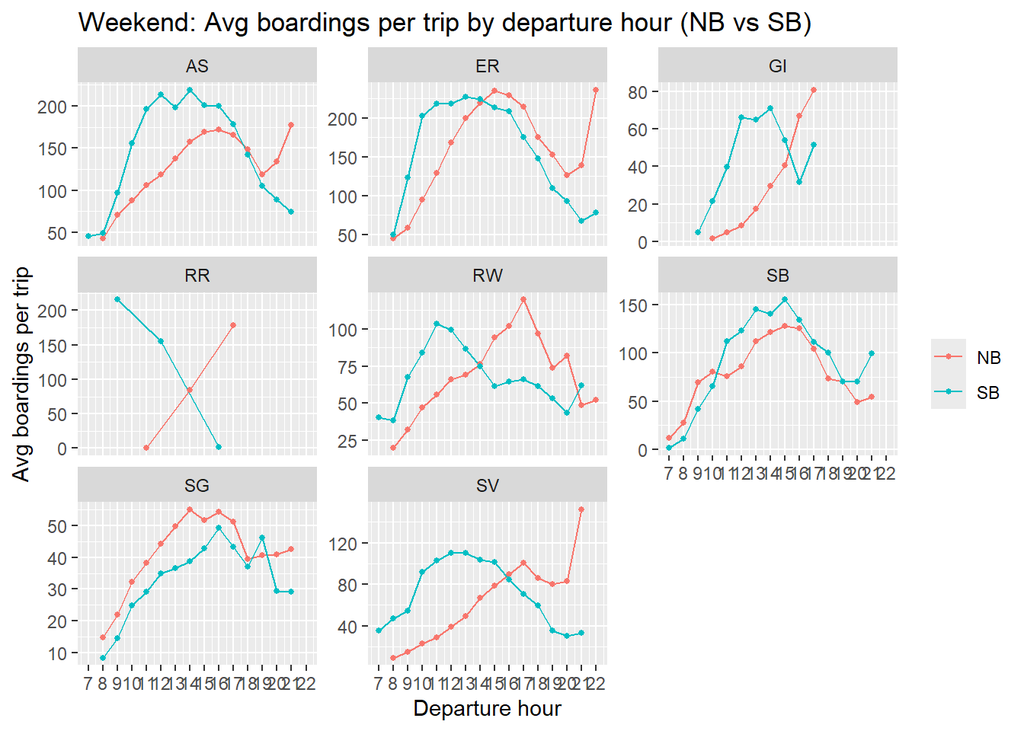

```r
ggplot(dir_hour_summary %>% filter(day_type == "Weekend"),
       aes(x = dep_hour, y = avg_boardings_per_trip, color = route_direction)) +
  geom_line() +
  geom_point(size = 1) +
  facet_wrap(~ route_no, scales = "free_y") +
  scale_x_continuous(breaks = dir_hour_breaks) +
  labs(title = "Weekend: Avg boardings per trip by departure hour (NB vs SB)",
       x = "Departure hour", y = "Avg boardings per trip", color = NULL)
```

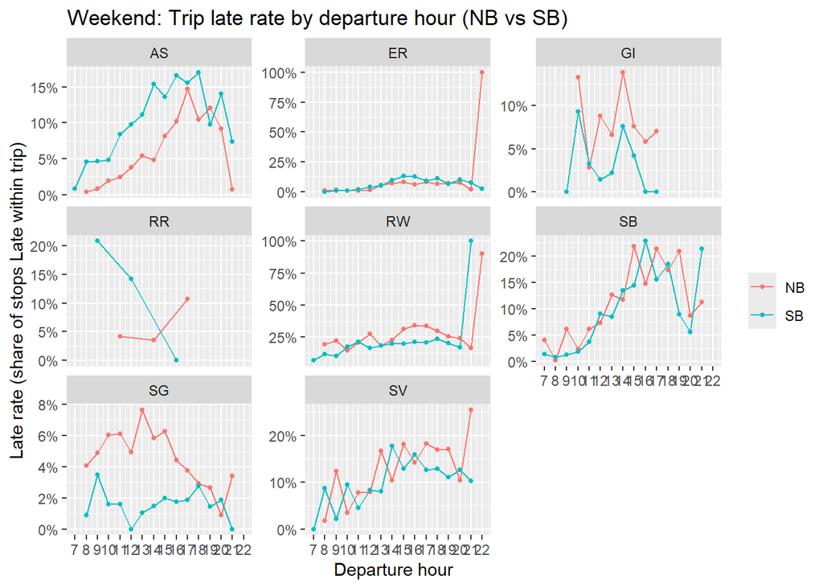

```r
ggplot(dir_hour_summary %>% filter(day_type == "Weekend"),
       aes(x = dep_hour, y = avg_late_rate, color = route_direction)) +
  geom_line() +
  geom_point(size = 1) +
  facet_wrap(~ route_no, scales = "free_y") +
  scale_x_continuous(breaks = dir_hour_breaks) +
  scale_y_continuous(labels = scales::percent_format()) +
  labs(title = "Weekend: Trip late rate by departure hour (NB vs SB)",
       x = "Departure hour", y = "Late rate (share of stops Late within trip)", color = NULL)
```

Several routes show directional asymmetry consistent with tidal commute patterns, where demand differs by direction at certain times. For some routes, one direction exhibits consistently higher late rates than the other, suggesting operational constraints rather than demand alone.

### Export outputs

The final step exports the main stop-level analysis sample `dat` to the project output directory as a compressed CSV (for sharing) and an RDS file (to preserve data types for reloads).

```r
export_dir <- file.path(base_dir, "stop_eda")
dir.create(export_dir, recursive = TRUE, showWarnings = FALSE)

readr::write_csv(dat, file.path(export_dir, "dat_stops_2024-01-01_2025-06-30_drop0425SB.csv.gz"))
saveRDS(dat, file.path(export_dir, "dat_stops_2024-01-01_2025-06-30_drop0425SB.rds"))
```